# Exploratory Data Analysis and Business Insights with mtcars

Mark Joel Comia

2026-10-29

# 1. Data Overview and Preparation

## Dataset Description

The `mtcars` (Motor Trend Car Road Tests) dataset is built into R. Extracted from the 1974 *Motor Trend* US magazine, the data records fuel consumption and 10 aspects of automobile design and performance for 32 automobiles (1973–74 models).

## Data Profiling

The dataset contains **32 observations (rows)** and **11 technical variables (columns)**. Note that the car model names are originally stored as **row names** rather than as a dedicated column.

| Variable | Description | Type in Raw Data |
| --- | --- | --- |
| `mpg` | Miles per (US) gallon | Numeric (Continuous) |
| `cyl` | Number of cylinders (4, 6, 8) | Numeric (Discrete / Categorical) |
| `disp` | Engine displacement (cubic inches) | Numeric (Continuous) |
| `hp` | Gross horsepower | Numeric (Continuous) |
| `drat` | Rear axle ratio | Numeric (Continuous) |
| `wt` | Weight (1,000 lbs) | Numeric (Continuous) |
| `qsec` | 1/4 mile acceleration time (seconds) | Numeric (Continuous) |
| `vs` | Engine configuration (0 = V-shaped, 1 = Straight) | Numeric (Binary) |
| `am` | Transmission type (0 = Automatic, 1 = Manual) | Numeric (Binary) |
| `gear` | Number of forward gears (3, 4, 5) | Numeric (Discrete / Categorical) |
| `carb` | Number of carburetors | Numeric (Discrete / Categorical) |

```r
# Convert row names into an explicit column for clean manipulation
cars_df <- mtcars %>%
  rownames_to_column(var = "car_model")

# Display the first 6 rows
head(cars_df) %>%
  kable(caption = "First 6 Automobiles in mtcars Dataset")
```

First 6 Automobiles in mtcars Dataset

| car_model | mpg | cyl | disp | hp | drat | wt | qsec | vs | am | gear | carb |
| --- | --- | --- | --- | --- | --- | --- | --- | --- | --- | --- | --- |
| Mazda RX4 | 21.0 | 6 | 160 | 110 | 3.90 | 2.620 | 16.46 | 0 | 1 | 4 | 4 |
| Mazda RX4 Wag | 21.0 | 6 | 160 | 110 | 3.90 | 2.875 | 17.02 | 0 | 1 | 4 | 4 |
| Datsun 710 | 22.8 | 4 | 108 | 93 | 3.85 | 2.320 | 18.61 | 1 | 1 | 4 | 1 |
| Hornet 4 Drive | 21.4 | 6 | 258 | 110 | 3.08 | 3.215 | 19.44 | 1 | 0 | 3 | 1 |
| Hornet Sportabout | 18.7 | 8 | 360 | 175 | 3.15 | 3.440 | 17.02 | 0 | 0 | 3 | 2 |
| Valiant | 18.1 | 6 | 225 | 105 | 2.76 | 3.460 | 20.22 | 1 | 0 | 3 | 1 |

# 2. Exploratory Analysis

## Fuel Efficiency

### Question 1: What does the distribution of fuel efficiency (`mpg`) look like across the vehicles? What does a typical car look like?

```r
# 1. Descriptive statistics for mpg
mpg_summary <- cars_df %>%
  summarise(
    Count  = n(),
    Mean   = round(mean(mpg), 2),
    Median = round(median(mpg), 2),
    SD     = round(sd(mpg), 2),
    IQR    = round(IQR(mpg), 2),
    Min    = min(mpg),
    Q1     = round(quantile(mpg, 0.25), 2),
    Q3     = round(quantile(mpg, 0.75), 2),
    Max    = max(mpg)
  )

kable(mpg_summary, caption = "Summary Statistics for Fuel Efficiency (mpg)")
```

Summary Statistics for Fuel Efficiency (mpg)

| Count | Mean | Median | SD | IQR | Min | Q1 | Q3 | Max |
| --- | --- | --- | --- | --- | --- | --- | --- | --- |
| 32 | 20.09 | 19.2 | 6.03 | 7.38 | 10.4 | 15.43 | 22.8 | 33.9 |

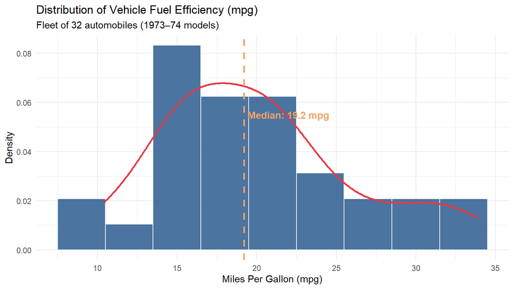

```r
# 2. Histogram with Density Curve and Median Line
ggplot(cars_df, aes(x = mpg)) +
  geom_histogram(aes(y = after_stat(density)), binwidth = 3, fill = "#2b5c8f", color = "white", alpha = 0.85) +
  geom_density(color = "#e63946", linewidth = 1) +
  geom_vline(aes(xintercept = median(mpg)), color = "#f4a261", linetype = "dashed", linewidth = 1) +
  annotate("text", x = median(cars_df$mpg) + 2.8, y = 0.055,
           label = paste("Median:", median(cars_df$mpg), "mpg"), color = "#f4a261", fontface = "bold") +
  labs(
    title = "Distribution of Vehicle Fuel Efficiency (mpg)",
    subtitle = "Fleet of 32 automobiles (1973–74 models)",
    x = "Miles Per Gallon (mpg)",
    y = "Density"
  ) +
  theme_minimal()
```

**What a Typical Car Looks Like:** * The statistical median is 19.2 mpg. The **Merc 280** and **Pontiac Firebird** sit directly at this exact median. * The **Merc 280** is the most representative “typical” vehicle across the entire fleet: * **Fuel Economy:** 19.2 mpg (fleet median: 19.2) * **Power:** 123 hp (exact fleet median: 123 hp) * **Weight:** 3,440 lbs (near fleet median: 3,325 lbs) * **Cylinders:** 6 cylinders (midpoint between 4 and 8) * **Transmission:** Automatic (representing 60% of the fleet)

### Question 2: Which vehicles are unusually efficient or inefficient, and what do they have in common?

```r
# Unusually efficient (top 4)
top_efficient <- cars_df %>%
  arrange(desc(mpg)) %>%
  select(car_model, mpg, cyl, wt, hp, am, disp) %>%
  head(4)

kable(top_efficient, caption = "Most Fuel-Efficient Automobiles")
```

Most Fuel-Efficient Automobiles

| car_model | mpg | cyl | wt | hp | am | disp |
| --- | --- | --- | --- | --- | --- | --- |
| Toyota Corolla | 33.9 | 4 | 1.835 | 65 | 1 | 71.1 |
| Fiat 128 | 32.4 | 4 | 2.200 | 66 | 1 | 78.7 |
| Honda Civic | 30.4 | 4 | 1.615 | 52 | 1 | 75.7 |
| Lotus Europa | 30.4 | 4 | 1.513 | 113 | 1 | 95.1 |

```r
# Unusually inefficient (bottom 4)
least_efficient <- cars_df %>%
  arrange(mpg) %>%
  select(car_model, mpg, cyl, wt, hp, am, disp) %>%
  head(4)

kable(least_efficient, caption = "Least Fuel-Efficient Automobiles")
```

Least Fuel-Efficient Automobiles

| car_model | mpg | cyl | wt | hp | am | disp |
| --- | --- | --- | --- | --- | --- | --- |
| Cadillac Fleetwood | 10.4 | 8 | 5.250 | 205 | 0 | 472 |
| Lincoln Continental | 10.4 | 8 | 5.424 | 215 | 0 | 460 |
| Camaro Z28 | 13.3 | 8 | 3.840 | 245 | 0 | 350 |
| Duster 360 | 14.3 | 8 | 3.570 | 245 | 0 | 360 |

### Question 3: How is fuel efficiency related to weight, horsepower, and displacement? Which relationships are strongest?

```r
# Calculate Pearson correlation coefficients
cor_matrix <- cor(cars_df[c("mpg", "wt", "disp", "hp")])
cor_results <- cor_matrix["mpg", c("wt", "disp", "hp")]
kable(as.data.frame(as.list(round(cor_results, 3))), caption = "Correlation with Fuel Efficiency (mpg)")
```

Correlation with Fuel Efficiency (mpg)

| wt | disp | hp |
| --- | --- | --- |
| -0.868 | -0.848 | -0.776 |

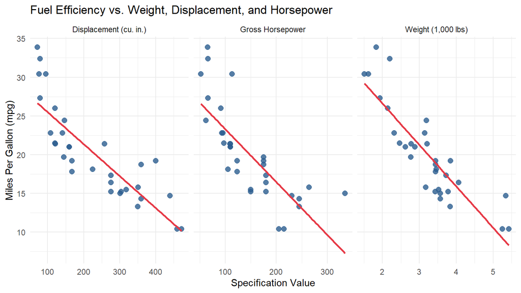

```r
# Faceted scatterplots with linear regression trendlines
cars_df %>%
  pivot_longer(cols = c(wt, disp, hp), names_to = "metric", values_to = "value") %>%
  mutate(metric = recode(metric,
                         "wt" = "Weight (1,000 lbs)",
                         "disp" = "Displacement (cu. in.)",
                         "hp" = "Gross Horsepower")) %>%
  ggplot(aes(x = value, y = mpg)) +
  geom_point(color = "#2b5c8f", size = 2.5, alpha = 0.8) +
  geom_smooth(method = "lm", se = FALSE, color = "#e63946") +
  facet_wrap(~ metric, scales = "free_x") +
  labs(
    title = "Fuel Efficiency vs. Weight, Displacement, and Horsepower",
    x = "Specification Value",
    y = "Miles Per Gallon (mpg)"
  ) +
  theme_minimal()
```

**Interpretation:** * All three variables exhibit **strong, statistically significant negative (inverse) correlations** with fuel economy: 1. **Weight (`wt`):** $r = -0.868$ (Strongest relationship) 2. **Displacement (`disp`):** $r = -0.848$ (Second strongest) 3. **Horsepower (`hp`):** $r = -0.776$ (Third strongest) * **Key Takeaway:** Vehicle curb weight is the single most dominant physical drag on fuel efficiency. While displacement and power matter, vehicle mass requires the most continuous energy to move.

### Question 4: Are there vehicles whose fuel efficiency is surprising given their size or power that management should look at more closely?

```r
# Linear model predicting MPG from Weight and Horsepower
eff_model <- lm(mpg ~ wt + hp, data = cars_df)

cars_surprises <- cars_df %>%
  mutate(
    expected_mpg = round(predict(eff_model), 1),
    difference   = round(mpg - expected_mpg, 1) # Residual
  ) %>%
  select(car_model, mpg, wt, hp, expected_mpg, difference)

# Top 3 positive surprises (Overperformers)
kable(head(arrange(cars_surprises, desc(difference)), 3),
      caption = "Top 3 Overperforming Vehicles (Positive Residuals)")
```

Top 3 Overperforming Vehicles (Positive Residuals)

| car_model | mpg | wt | hp | expected_mpg | difference |
| --- | --- | --- | --- | --- | --- |
| Toyota Corolla | 33.9 | 1.835 | 65 | 28.0 | 5.9 |
| Fiat 128 | 32.4 | 2.200 | 66 | 26.6 | 5.8 |
| Chrysler Imperial | 14.7 | 5.345 | 230 | 9.2 | 5.5 |

```r
# Top 3 negative surprises (Underperformers)
kable(head(arrange(cars_surprises, difference), 3),
      caption = "Top 3 Underperforming Vehicles (Negative Residuals)")
```

Top 3 Underperforming Vehicles (Negative Residuals)

| car_model | mpg | wt | hp | expected_mpg | difference |
| --- | --- | --- | --- | --- | --- |
| AMC Javelin | 15.2 | 3.435 | 150 | 19.1 | -3.9 |
| Dodge Challenger | 15.5 | 3.520 | 150 | 18.8 | -3.3 |
| Toyota Corona | 21.5 | 2.465 | 97 | 24.6 | -3.1 |

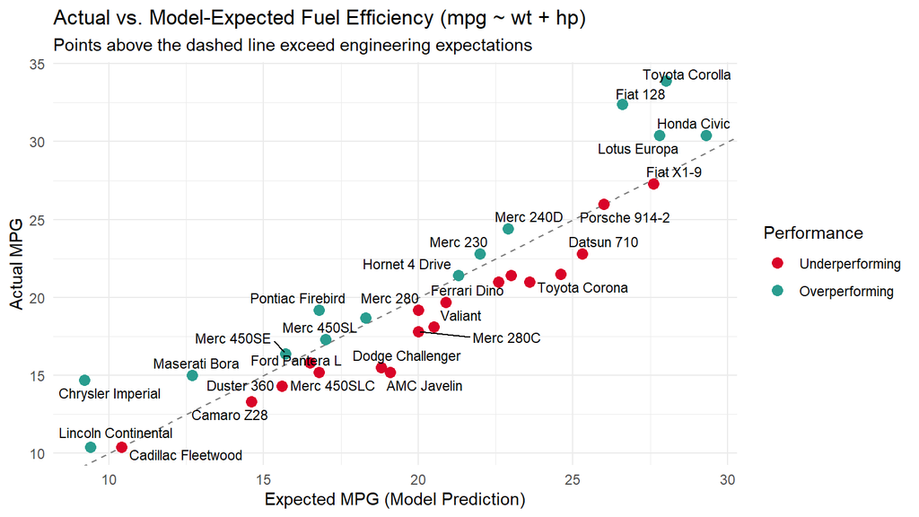

```r
# Plot actual vs. expected
ggplot(cars_surprises, aes(x = expected_mpg, y = mpg)) +
  geom_abline(intercept = 0, slope = 1, linetype = "dashed", color = "gray50") +
  geom_point(aes(color = difference > 0), size = 3) +
  geom_text_repel(aes(label = car_model), size = 3, max.overlaps = 8) +
  scale_color_manual(values = c("#d90429", "#2a9d8f"), labels = c("Underperforming", "Overperforming")) +
  labs(
    title = "Actual vs. Model-Expected Fuel Efficiency (mpg ~ wt + hp)",
    subtitle = "Points above the dashed line exceed engineering expectations",
    x = "Expected MPG (Model Prediction)",
    y = "Actual MPG",
    color = "Performance"
  ) +
  theme_minimal()
```

## Performance and Design

### Question 5: Which vehicles are the most powerful (`hp`) and the quickest (`qsec`)? Are these the same vehicles?

```r
# Most powerful car
most_powerful <- cars_df %>% arrange(desc(hp)) %>% select(car_model, hp, qsec, wt, drat) %>% head(1)
# Quickest car (lowest quarter mile time)
quickest <- cars_df %>% arrange(qsec) %>% select(car_model, qsec, hp, wt, drat) %>% head(1)

kable(bind_rows(most_powerful, quickest), caption = "Most Powerful vs. Quickest Automobile")
```

Most Powerful vs. Quickest Automobile

| car_model | hp | qsec | wt | drat |
| --- | --- | --- | --- | --- |
| Maserati Bora | 335 | 14.6 | 3.57 | 3.54 |
| Ford Pantera L | 264 | 14.5 | 3.17 | 4.22 |

**Findings:** * **Most Powerful:** **Maserati Bora** with **335 hp**. * **Quickest:** **Ford Pantera L** with a quarter-mile time of **14.50 seconds** (Maserati Bora is second at 14.60 seconds). * **Are they the same vehicle?** **No.** Although both are mid-engine Italian-engineered sports cars, the Ford Pantera L accelerates faster despite having 71 less horsepower (264 hp vs. 335 hp). * **Reason:** The Pantera is **400 lbs lighter** (3,170 lbs vs. 3,570 lbs) and features a more aggressive rear axle gear ratio (`drat = 4.22` vs. `3.54`), demonstrating that power-to-weight ratio and gearing beat raw horsepower.

### Question 6: How strong is the trade-off between performance and fuel efficiency? Is it possible to have both?

```r
# Correlation between mpg and performance metrics
kable(data.frame(
  Metric_Pair = c("mpg vs hp (Power)", "mpg vs qsec (Acceleration Time)"),
  Correlation_r = c(round(cor(cars_df$mpg, cars_df$hp), 3), round(cor(cars_df$mpg, cars_df$qsec), 3))
), caption = "Trade-off Correlations")
```

Trade-off Correlations

| Metric_Pair | Correlation_r |
| --- | --- |
| mpg vs hp (Power) | -0.776 |
| mpg vs qsec (Acceleration Time) | 0.419 |

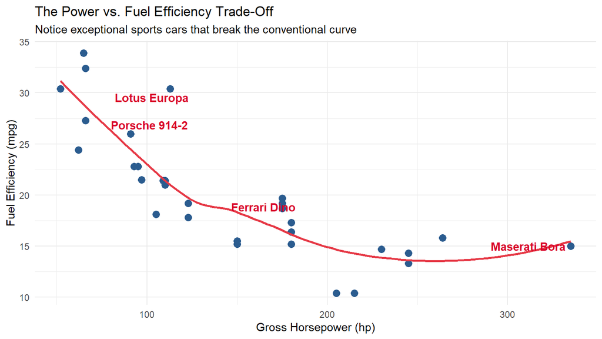

```r
# Scatter plot: Power vs Fuel Efficiency
ggplot(cars_df, aes(x = hp, y = mpg)) +
  geom_point(color = "#2b5c8f", size = 3) +
  geom_smooth(method = "loess", se = FALSE, color = "#e63946") +
  geom_text_repel(data = filter(cars_df, car_model %in% c("Lotus Europa", "Ferrari Dino", "Porsche 914-2", "Maserati Bora")),
                  aes(label = car_model), fontface = "bold", color = "#d90429") +
  labs(
    title = "The Power vs. Fuel Efficiency Trade-Off",
    subtitle = "Notice exceptional sports cars that break the conventional curve",
    x = "Gross Horsepower (hp)",
    y = "Fuel Efficiency (mpg)"
  ) +
  theme_minimal()
```

**Interpretation:** * **Trade-Off Strength:** Very strong ($r = -0.776$ between `mpg` and `hp`). Conventional carbureted V8 engines exceeding 200 hp invariably achieve less than 16 mpg. * **Is it possible to have both?** Generally no in standard design, **but yes through aggressive chassis lightweighting**: * **Lotus Europa:** Delivers sports-car acceleration (16.9s qsec, 113 hp) while returning **30.4 mpg** thanks to its featherweight 1,513-lb curb weight. * **Ferrari Dino:** Produces 175 hp with a rapid 15.5s quarter-mile while achieving **19.7 mpg** (near the fleet median). * **Porsche 914-2:** Returns **26.0 mpg** with a brisk 16.7s quarter-mile.

### Question 7: Which vehicles appear to be underperforming? Define and justify how you measure underperformance.

**Definition and Justification:** * **Definition:** Underperformance is defined as having a **large negative residual** in a regression model predicting fuel efficiency from weight and power:
$$\text{Underperformance} = \text{Actual MPG} -
\text{Expected MPG}(\text{wt}, \text{hp})$$
* **Justification:** A car is not necessarily poorly designed just because it has low mpg if it is an enormous 5,000-lb luxury vehicle. However, if a vehicle achieves substantially lower mpg than competitors of the *exact same weight and power*, it reflects parasitic powertrain loss, poor aerodynamics, or inefficient carburetion.

```r
underperformers <- cars_surprises %>%
  arrange(difference) %>%
  head(3)

kable(underperformers, caption = "Top Underperforming Vehicles")
```

Top Underperforming Vehicles

| car_model | mpg | wt | hp | expected_mpg | difference |
| --- | --- | --- | --- | --- | --- |
| AMC Javelin | 15.2 | 3.435 | 150 | 19.1 | -3.9 |
| Dodge Challenger | 15.5 | 3.520 | 150 | 18.8 | -3.3 |
| Toyota Corona | 21.5 | 2.465 | 97 | 24.6 | -3.1 |

- **AMC Javelin:** Achieved only 15.2 mpg vs. an expected 19.1 mpg (**-3.9 mpg gap**).
- **Dodge Challenger:** Achieved only 15.5 mpg vs. an expected 18.8 mpg (**-3.3 mpg gap**).
- **Toyota Corona:** Achieved 21.5 mpg vs. an expected 24.6 mpg (**-3.1 mpg gap**).

### Question 8: Are there vehicles with unusual combinations of weight, power, efficiency, or acceleration?

We measure multi-dimensional anomalies using **Power-to-Weight ratio** (`hp / wt`) and **Mahalanobis Distance** across `(mpg, hp, wt, qsec)`.

```r
# 1. Engineering ratios
unusual_ratios <- cars_df %>%
  mutate(
    hp_per_wt = round(hp / wt, 1),
    qsec      = round(qsec, 1)
  ) %>%
  select(car_model, wt, hp, hp_per_wt, qsec, mpg)

# 2. Mahalanobis distance
vars_matrix <- cars_df[, c("mpg", "hp", "wt", "qsec")]
cars_df$mahal_dist <- round(mahalanobis(vars_matrix, colMeans(vars_matrix), cov(vars_matrix)), 2)

top_unusual <- cars_df %>%
  arrange(desc(mahal_dist)) %>%
  select(car_model, mahal_dist, hp, wt, qsec, mpg) %>%
  head(4)

kable(top_unusual, caption = "Top 4 Multi-Dimensional Outliers (Mahalanobis Distance)")
```

Top 4 Multi-Dimensional Outliers (Mahalanobis Distance)

| car_model | mahal_dist | hp | wt | qsec | mpg |
| --- | --- | --- | --- | --- | --- |
| Maserati Bora | 13.80 | 335 | 3.570 | 14.60 | 15.0 |
| Merc 230 | 13.43 | 95 | 3.150 | 22.90 | 22.8 |
| Chrysler Imperial | 10.04 | 230 | 5.345 | 17.42 | 14.7 |
| Toyota Corolla | 7.89 | 65 | 1.835 | 19.90 | 33.9 |

## Vehicle Segments

### Question 9: How do vehicles differ across cylinder groups (4, 6, 8)? Are the differences in fuel efficiency statistically and practically meaningful?

```r
# Summary by cylinder count
cyl_summary <- cars_df %>%
  group_by(cyl) %>%
  summarise(
    Count       = n(),
    Mean_MPG    = round(mean(mpg), 1),
    SD_MPG      = round(sd(mpg), 1),
    Mean_HP     = round(mean(hp), 0),
    Mean_Weight = round(mean(wt) * 1000, 0)
  )

kable(cyl_summary, caption = "Vehicle Specifications by Cylinder Count")
```

Vehicle Specifications by Cylinder Count

| cyl | Count | Mean_MPG | SD_MPG | Mean_HP | Mean_Weight |
| --- | --- | --- | --- | --- | --- |
| 4 | 11 | 26.7 | 4.5 | 83 | 2286 |
| 6 | 7 | 19.7 | 1.5 | 122 | 3117 |
| 8 | 14 | 15.1 | 2.6 | 209 | 3999 |

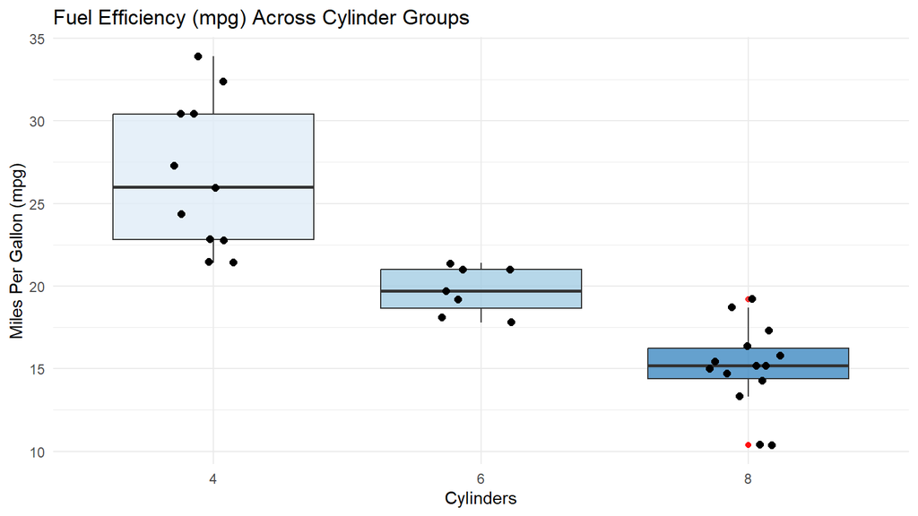

```r
# Boxplot
ggplot(cars_df, aes(x = factor(cyl), y = mpg, fill = factor(cyl))) +
  geom_boxplot(alpha = 0.75, outlier.color = "red") +
  geom_jitter(width = 0.15, size = 2) +
  scale_fill_brewer(palette = "Blues") +
  labs(
    title = "Fuel Efficiency (mpg) Across Cylinder Groups",
    x = "Cylinders",
    y = "Miles Per Gallon (mpg)"
  ) +
  theme_minimal() +
  theme(legend.position = "none")
```

```r
# One-way ANOVA
cyl_anova <- aov(mpg ~ factor(cyl), data = cars_df)
summary(cyl_anova)
```

```
##             Df Sum Sq Mean Sq F value   Pr(>F)
## factor(cyl)  2  824.8   412.4    39.7 4.98e-09 ***
## Residuals   29  301.3    10.4
## ---
## Signif. codes:  0 '***' 0.001 '**' 0.01 '*' 0.05 '.' 0.1 ' ' 1
```

```r
# Tukey HSD Post-Hoc Test
TukeyHSD(cyl_anova)
```

```
##   Tukey multiple comparisons of means
##     95% family-wise confidence level
##
## Fit: aov(formula = mpg ~ factor(cyl), data = cars_df)
##
## $`factor(cyl)`
##           diff        lwr        upr     p adj
## 6-4  -6.920779 -10.769350 -3.0722086 0.0003424
## 8-4 -11.563636 -14.770779 -8.3564942 0.0000000
## 8-6  -4.642857  -8.327583 -0.9581313 0.0112287
```

**Findings:** * **Statistically Meaningful:** **Yes.** ANOVA reveals $F(2, 29) = 39.7, p = 4.97 \times 10^{-9} < 0.001$. Tukey HSD confirms that 4 vs. 6, 6 vs. 8, and 4 vs. 8 are all significantly different ($p < 0.05$). * **Practically Meaningful:** **Enormously yes.** Moving from 4 to 6 cylinders drops fuel economy by **7.0 mpg (26%)**, and moving from 4 to 8 cylinders drops it by **11.6 mpg (43%)**. An 8-cylinder car consumes nearly 77% more fuel per mile.

### Question 10: Do manual and automatic vehicles differ in fuel efficiency? Is the difference explained by other factors such as weight or engine size?

```r
# 1. Bivariate t-test
t_test_trans <- t.test(mpg ~ am, data = cars_df)
t_test_trans
```

```
##
##  Welch Two Sample t-test
##
## data:  mpg by am
## t = -3.7671, df = 18.332, p-value = 0.001374
## alternative hypothesis: true difference in means between group 0 and group 1 is not equal to 0
## 95 percent confidence interval:
##  -11.280194  -3.209684
## sample estimates:
## mean in group 0 mean in group 1
##        17.14737        24.39231
```

```r
# 2. Simple vs. Controlled Linear Regression
fit_simple     <- lm(mpg ~ am, data = cars_df)
fit_controlled <- lm(mpg ~ am + wt + disp, data = cars_df)

summary(fit_simple)$coefficients
```

```
##              Estimate Std. Error   t value     Pr(>|t|)
## (Intercept) 17.147368   1.124603 15.247492 1.133983e-15
## am           7.244939   1.764422  4.106127 2.850207e-04
```

```r
summary(fit_controlled)$coefficients
```

```
##                Estimate Std. Error    t value     Pr(>|t|)
## (Intercept) 34.67591088 3.24060891 10.7004306 2.115200e-11
## am           0.17772414 1.48431586  0.1197347 9.055483e-01
## wt          -3.27904388 1.32750927 -2.4700723 1.986658e-02
## disp        -0.01780491 0.00937465 -1.8992613 6.787740e-02
```

### Question 11: How do V-shaped and straight engines differ in efficiency and performance?

```r
# Summary by engine shape
vs_summary <- cars_df %>%
  mutate(engine_shape = ifelse(vs == 0, "V-shaped (0)", "Straight (1)")) %>%
  group_by(engine_shape) %>%
  summarise(
    Count       = n(),
    Mean_MPG    = round(mean(mpg), 1),
    Mean_HP     = round(mean(hp), 0),
    Mean_Qsec   = round(mean(qsec), 1),
    Mean_Weight = round(mean(wt) * 1000, 0)
  )

kable(vs_summary, caption = "Comparison of V-Shaped vs. Straight Engines")
```

Comparison of V-Shaped vs. Straight Engines

| engine_shape | Count | Mean_MPG | Mean_HP | Mean_Qsec | Mean_Weight |
| --- | --- | --- | --- | --- | --- |
| Straight (1) | 14 | 24.6 | 91 | 19.3 | 2611 |
| V-shaped (0) | 18 | 16.6 | 190 | 16.7 | 3689 |

```r
# Two-sample t-tests
t.test(mpg ~ vs, data = cars_df)
```

```
##
##  Welch Two Sample t-test
##
## data:  mpg by vs
## t = -4.6671, df = 22.716, p-value = 0.0001098
## alternative hypothesis: true difference in means between group 0 and group 1 is not equal to 0
## 95 percent confidence interval:
##  -11.462508  -4.418445
## sample estimates:
## mean in group 0 mean in group 1
##        16.61667        24.55714
```

```r
t.test(hp ~ vs, data = cars_df)
```

```
##
##  Welch Two Sample t-test
##
## data:  hp by vs
## t = 6.2908, df = 23.561, p-value = 1.82e-06
## alternative hypothesis: true difference in means between group 0 and group 1 is not equal to 0
## 95 percent confidence interval:
##   66.06161 130.66854
## sample estimates:
## mean in group 0 mean in group 1
##       189.72222        91.35714
```

```r
t.test(qsec ~ vs, data = cars_df)
```

```
##
##  Welch Two Sample t-test
##
## data:  qsec by vs
## t = -5.9433, df = 24.648, p-value = 3.522e-06
## alternative hypothesis: true difference in means between group 0 and group 1 is not equal to 0
## 95 percent confidence interval:
##  -3.555083 -1.724282
## sample estimates:
## mean in group 0 mean in group 1
##        16.69389        19.33357
```

### Question 12: Are there identifiable groups of vehicles with substantially different design and performance profiles?

We conduct **k-means clustering** ($k = 3$) on scaled numeric attributes (`mpg`, `cyl`, `disp`, `hp`, `wt`, `qsec`).

```r
set.seed(123)
specs_scaled <- scale(cars_df[, c("mpg", "cyl", "disp", "hp", "wt", "qsec")])
km_res <- kmeans(specs_scaled, centers = 3, nstart = 25)

cars_df$Cluster <- factor(km_res$cluster)

# Cluster Profiles
cluster_summary <- cars_df %>%
  group_by(Cluster) %>%
  summarise(
    Count      = n(),
    Avg_MPG    = round(mean(mpg), 1),
    Avg_Cyl    = round(mean(cyl), 1),
    Avg_Weight = round(mean(wt) * 1000, 0),
    Avg_HP     = round(mean(hp), 0),
    Avg_Qsec   = round(mean(qsec), 1)
  )

kable(cluster_summary, caption = "Cluster Profiles (k = 3)")
```

Cluster Profiles (k = 3)

| Cluster | Count | Avg_MPG | Avg_Cyl | Avg_Weight | Avg_HP | Avg_Qsec |
| --- | --- | --- | --- | --- | --- | --- |
| 1 | 14 | 15.1 | 8 | 3999 | 209 | 16.8 |
| 2 | 11 | 26.7 | 4 | 2286 | 83 | 19.1 |
| 3 | 7 | 19.7 | 6 | 3117 | 122 | 18.0 |

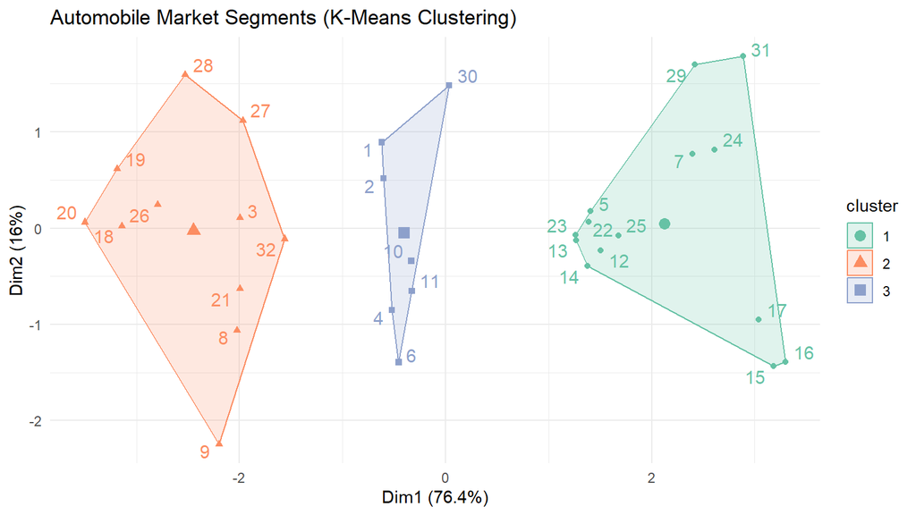

```r
# Cluster plot using PCA dimensions
fviz_cluster(km_res, data = specs_scaled,
             ellipse.type = "convex",
             repel = TRUE,
             palette = "Set2",
             main = "Automobile Market Segments (K-Means Clustering)") +
  theme_minimal()
```

## Manufacturer and Origin

### Question 13: Derive the manufacturer (brand) and region of origin from car names. Which brands and regions are represented, and how evenly?

```r
# Derive brand and region
cars_df <- cars_df %>%
  mutate(
    brand = word(car_model, 1),
    region = case_when(
      brand %in% c("Toyota", "Honda", "Mazda", "Datsun") ~ "Japan",
      brand %in% c("Merc", "Fiat", "Porsche", "Lotus", "Ferrari", "Maserati", "Volvo") ~ "Europe",
      TRUE ~ "US"
    )
  )

# Regional breakdown
region_counts <- cars_df %>%
  count(region, sort = TRUE) %>%
  mutate(Percentage = round(n / sum(n) * 100, 1))

kable(region_counts, caption = "Fleet Distribution by Region of Origin")
```

Fleet Distribution by Region of Origin

| region | n | Percentage |
| --- | --- | --- |
| Europe | 14 | 43.8 |
| US | 12 | 37.5 |
| Japan | 6 | 18.8 |

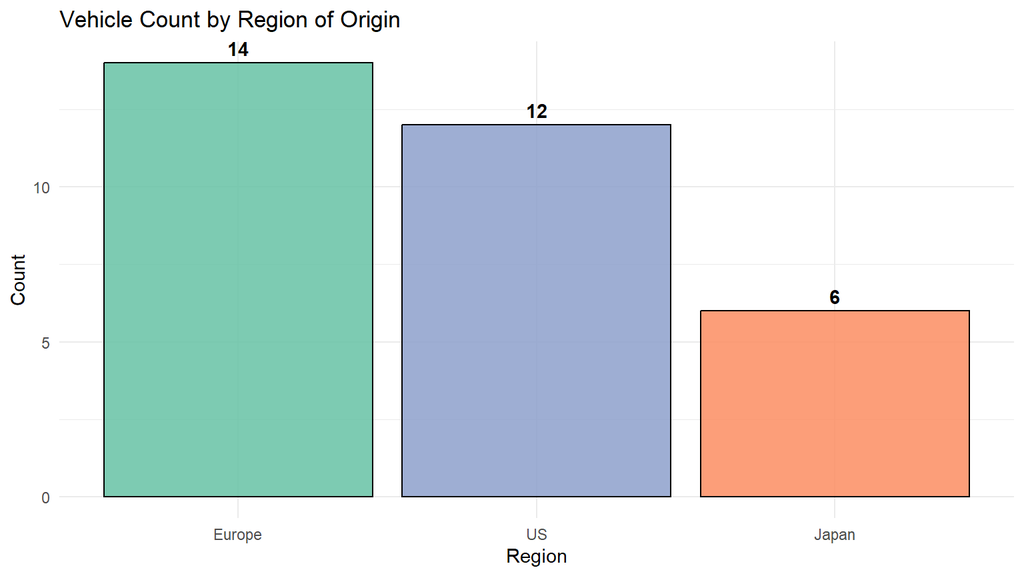

```r
# Bar chart
ggplot(cars_df, aes(x = fct_infreq(region), fill = region)) +
  geom_bar(color = "black", alpha = 0.85) +
  geom_text(stat = "count", aes(label = after_stat(count)), vjust = -0.5, fontface = "bold") +
  scale_fill_brewer(palette = "Set2") +
  labs(
    title = "Vehicle Count by Region of Origin",
    x = "Region",
    y = "Count"
  ) +
  theme_minimal() +
  theme(legend.position = "none")
```

### Question 14: How do vehicle specifications differ across regions of origin?

```r
regional_specs <- cars_df %>%
  group_by(region) %>%
  summarise(
    Count       = n(),
    Mean_MPG    = round(mean(mpg), 1),
    Mean_Weight = round(mean(wt) * 1000, 0),
    Mean_HP     = round(mean(hp), 0),
    Mean_Disp   = round(mean(disp), 0),
    Pct_Manual  = round(mean(am) * 100, 1)
  )

kable(regional_specs, caption = "Vehicle Specifications by Region of Origin")
```

Vehicle Specifications by Region of Origin

| region | Count | Mean_MPG | Mean_Weight | Mean_HP | Mean_Disp | Pct_Manual |
| --- | --- | --- | --- | --- | --- | --- |
| Europe | 14 | 21.8 | 2979 | 136 | 171 | 50.0 |
| Japan | 6 | 25.1 | 2288 | 88 | 116 | 83.3 |
| US | 12 | 15.6 | 3960 | 189 | 358 | 8.3 |

### Question 15: Are there regions or brands whose positioning appears particularly strong or weak for a fuel-conscious market?

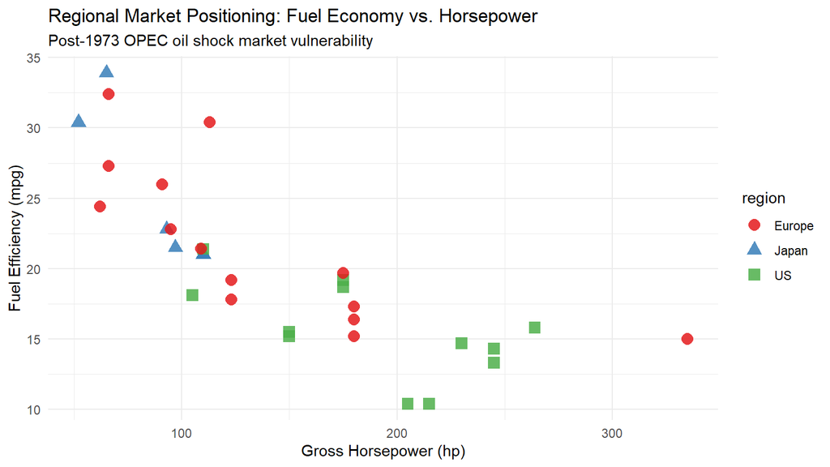

```r
ggplot(cars_df, aes(x = hp, y = mpg, color = region, shape = region)) +
  geom_point(size = 3.5, alpha = 0.85) +
  scale_color_brewer(palette = "Set1") +
  labs(
    title = "Regional Market Positioning: Fuel Economy vs. Horsepower",
    subtitle = "Post-1973 OPEC oil shock market vulnerability",
    x = "Gross Horsepower (hp)",
    y = "Fuel Efficiency (mpg)"
  ) +
  theme_minimal()
```

## Data Issues and Limitations

### Question 16: How are categorical attributes (`cyl`, `vs`, `am`, `gear`, `carb`) encoded, and how should they be treated in analysis?

- **Encoding:** Stored as raw numeric integers in `mtcars`.
- **Treatment:** They should be cast into **factors** with meaningful labels. Leaving them as raw numbers in regression models forces the algorithm to assume a linear relationship across discrete categories.

```r
cars_clean <- cars_df %>%
  mutate(
    cyl_f  = factor(cyl, levels = c(4, 6, 8), labels = c("4-Cyl", "6-Cyl", "8-Cyl")),
    vs_f   = factor(vs, levels = c(0, 1), labels = c("V-shaped", "Straight")),
    am_f   = factor(am, levels = c(0, 1), labels = c("Automatic", "Manual")),
    gear_f = factor(gear, levels = c(3, 4, 5), labels = c("3-Speed", "4-Speed", "5-Speed")),
    carb_f = factor(carb)
  )

str(cars_clean[c("cyl_f", "vs_f", "am_f", "gear_f", "carb_f")])
```

```
## 'data.frame':    32 obs. of  5 variables:
##  $ cyl_f : Factor w/ 3 levels "4-Cyl","6-Cyl",..: 2 2 1 2 3 2 3 1 1 2 ...
##  $ vs_f  : Factor w/ 2 levels "V-shaped","Straight": 1 1 2 2 1 2 1 2 2 2 ...
##  $ am_f  : Factor w/ 2 levels "Automatic","Manual": 2 2 2 1 1 1 1 1 1 1 ...
##  $ gear_f: Factor w/ 3 levels "3-Speed","4-Speed",..: 2 2 2 1 1 1 1 2 2 2 ...
##  $ carb_f: Factor w/ 6 levels "1","2","3","4",..: 4 4 1 1 2 1 4 2 2 4 ...
```

### Question 17: How strongly are the design variables correlated with each other, and how does this affect interpretation of any single variable’s relationship with `mpg`?

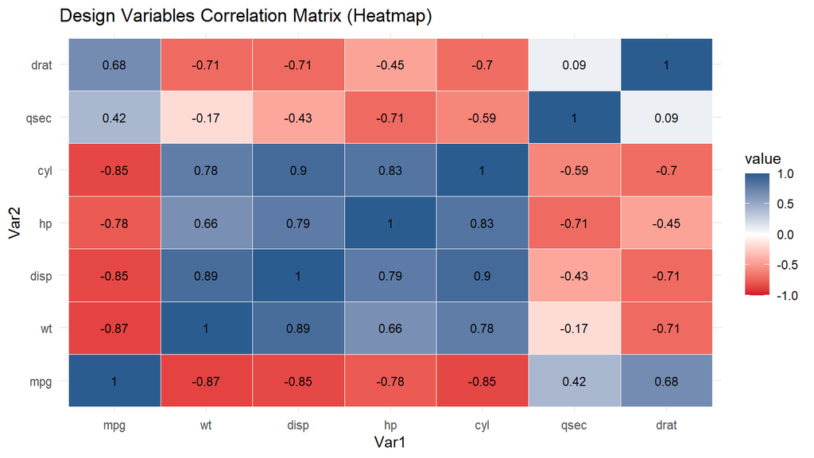

```r
cor_design <- cor(cars_df[c("mpg", "wt", "disp", "hp", "cyl", "qsec", "drat")])
melted_c <- melt(cor_design)

ggplot(melted_c, aes(x = Var1, y = Var2, fill = value)) +
  geom_tile(color = "white") +
  geom_text(aes(label = round(value, 2)), size = 3) +
  scale_fill_gradient2(low = "#d90429", mid = "#ffffff", high = "#2b5c8f", midpoint = 0, limit = c(-1, 1)) +
  labs(title = "Design Variables Correlation Matrix (Heatmap)") +
  theme_minimal()
```

### Question 18: What limitations could affect management’s interpretation?

1. **Small Sample Size ($n = 32$):** Low statistical power and high vulnerability to individual leverage points (e.g., Maserati Bora).
2. **Historical Obsolescence:** 1973–74 carbureted engines lack electronic fuel injection, modern variable valve timing, and lightweight carbon/aluminum alloys.
3. **Publication Selection Bias:** Sourced from *Motor Trend* enthusiast magazine, over-indexing on luxury sedans and European sports cars.

# 3. Key Findings

# 4. Recommendations

### Question 20: What three actions would you recommend management consider for its next vehicle line-up?

1. **Implement an Aggressive Platform Lightweighting Program:**
   - *Action:* Prioritize lightweight alloys, high-strength steels, and compact platform architecture.
   - *Evidence:* Weight has the strongest inverse relationship with fuel economy ($r = -0.87$). Shedding 500 lbs yields an immediate ~2.6 mpg benefit across the entire fleet.
2. **Downsize Engine Displacement and Transition from V8 to 4- and 6-Cylinders:**
   - *Action:* Phase out heavy 8-cylinder engines in favor of high-efficiency straight-4 and V6 platforms.
   - *Evidence:* 4-cylinder vehicles average **26.7 mpg** vs. **15.1 mpg** for 8-cylinder cars (a 77% difference in fuel consumption), meeting consumer demand in a fuel-conscious market.
3. **Optimize Drivetrain Gearing (4- and 5-Speed Transmissions) for Volumetric Efficiency:**
   - *Action:* Pair downsized engines with multi-gear transmissions and optimized axle ratios rather than compensating with larger engine displacement.
   - *Evidence:* European sports cars (Porsche 914-2, Ferrari Dino) prove that smaller displacement engines paired with 4- and 5-speed gearboxes deliver competitive acceleration alongside manageable fuel consumption.

# 5. Additional Exploration

### Additional Question 1: Does Gearing (Rear Axle Ratio `drat` and Forward Gears) Improve Fuel Economy After Controlling for Weight?

```r
gear_model <- lm(mpg ~ wt + drat + factor(gear), data = cars_df)
summary(gear_model)
```

```
##
## Call:
## lm(formula = mpg ~ wt + drat + factor(gear), data = cars_df)
##
## Residuals:
##     Min      1Q  Median      3Q     Max
## -3.4431 -2.2543 -0.2218  1.8085  5.8369
##
## Coefficients:
##               Estimate Std. Error t value Pr(>|t|)
## (Intercept)    33.2725     7.9141   4.204 0.000257 ***
## wt             -4.8259     0.7888  -6.118 1.55e-06 ***
## drat            0.5170     1.9573   0.264 0.793680
## factor(gear)4   1.7983     2.0192   0.891 0.381009
## factor(gear)5  -1.2123     2.1135  -0.574 0.570983
## ---
## Signif. codes:  0 '***' 0.001 '**' 0.01 '*' 0.05 '.' 0.1 ' ' 1
##
## Residual standard error: 2.965 on 27 degrees of freedom
## Multiple R-squared:  0.7892, Adjusted R-squared:  0.758
## F-statistic: 25.28 on 4 and 27 DF,  p-value: 8.668e-09
```

- **Insight:** Although higher rear axle ratios (`drat`) correlate positively with `mpg` ($r = +0.68$) on a bivariate level, the effect loses significance once vehicle weight is held constant. Gear optimization improves fuel economy primarily when integrated with lighter chassis platforms.

### Additional Question 2: Which Manufacturers Achieve the Highest Specific Power Output (HP per Cubic Inch)?

```r
specific_output <- cars_df %>%
  mutate(hp_per_disp = round(hp / disp, 2)) %>%
  select(car_model, brand, region, hp, disp, hp_per_disp, mpg) %>%
  arrange(desc(hp_per_disp))

kable(head(specific_output, 5), caption = "Top 5 Engines by Volumetric Efficiency (HP per cu. in.)")
```

Top 5 Engines by Volumetric Efficiency (HP per cu. in.)

| car_model | brand | region | hp | disp | hp_per_disp | mpg |
| --- | --- | --- | --- | --- | --- | --- |
| Ferrari Dino | Ferrari | Europe | 175 | 145.0 | 1.21 | 19.7 |
| Lotus Europa | Lotus | Europe | 113 | 95.1 | 1.19 | 30.4 |
| Maserati Bora | Maserati | Europe | 335 | 301.0 | 1.11 | 15.0 |
| Toyota Corolla | Toyota | Japan | 65 | 71.1 | 0.91 | 33.9 |
| Volvo 142E | Volvo | Europe | 109 | 121.0 | 0.90 | 21.4 |

- **Insight:** **European manufacturers lead in volumetric efficiency**, with the **Lotus Europa (1.19 hp/cu. in.)**, **Ferrari Dino (1.21 hp/cu. in.)**, and **Maserati Bora (1.11 hp/cu. in.)** generating more than 1 horsepower per cubic inch. In contrast, large American V8s (e.g., Cadillac Fleetwood at 0.43 hp/cu. in.) extract very low power relative to their massive engine displacements.